# tidymetrics and shinydahs

2020-05-03

### Tidymetrics

Tidymetrics is a great package, developed by [Ramnath Vaidyanathan](https://www.datacamp.com/instructors/ramnath) and [David Robinson](http://varianceexplained.org/), in this package you can aggregated some particular dimensional modeling for understand the real changes in your data. Working with two types of parameter `cross_by` and `create_metrics` is possible develop data science Understood as

> “Data science […] goal is an especially human one: to gain insight and understanding” (Robinson,2017)

For the `cross_by` case, this function prerpare data to be aggregated in differntes ways useful for create dimensional modeling.

With `cross_by_periods` prepares data with the dates (calendar format) and you cand aggregated rolling windows(weeks,days,and more)

And `cross_by_dimensional` aggregated levels.

For example, with the last tidytuesday

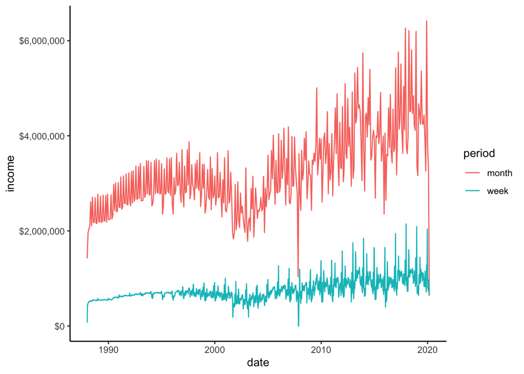

```r
grosses <- readr::read_csv('https://raw.githubusercontent.com/rfordatascience/tidytuesday/master/data/2020/2020-04-28/grosses.csv', guess_max = 40000)

grosses<-grosses%>%
  rename(date=week_ending)

grosses%>%
  filter(show=="The Phantom of the Opera")%>%
  cross_by_periods(c("week","month"))%>%
  summarize(income=sum(weekly_gross))%>%
  ggplot(aes(date,income,color=period))+
  geom_line()+
  scale_y_continuous(labels = dollar)
```

Is incredible!!! but now I wanna make new levels

```r
grosses%>%
  group_by(show)%>%
  count(sort = TRUE)
```

```
## # A tibble: 1,122 x 2
## # Groups:   show [1,122]
##    show                         n
##    <chr>                    <int>
##  1 The Phantom of the Opera  1677
##  2 Chicago                   1218
##  3 The Lion King             1166
##  4 Les Miserables            1040
##  5 Cats                       874
##  6 Wicked                     855
##  7 Mamma Mia!                 727
##  8 Beauty and the Beast       690
##  9 Rent                       647
## 10 Jersey Boys                588
## # … with 1,112 more rows
```

```r
grosses%>%
  filter(show %in% c("The Phantom of the Opera","Chicago",
                     "The Lion King","Les Miserables","Cats","Wicked",
                     "Mamma Mia!","Beauty and the Beast","Jersey Boys","Rent"))%>%
  cross_by_dimensions(show)%>%
  cross_by_periods(c("month","quarter","year"))%>%
  summarize(income=sum(weekly_gross),
            avg_ticket_price=mean(avg_ticket_price))%>%
  head()
```

```
## # A tibble: 6 x 5
## # Groups:   show, period [1]
##   show  period date        income avg_ticket_price
##   <chr> <chr>  <date>       <dbl>            <dbl>
## 1 All   month  1985-06-01 1848284             38.4
## 2 All   month  1985-07-01 1874127             38.9
## 3 All   month  1985-08-01 1900510             39.5
## 4 All   month  1985-09-01 2329653             38.8
## 5 All   month  1985-10-01 1836017             38.3
## 6 All   month  1985-11-01 1848151             38.5
```

And for design the graph

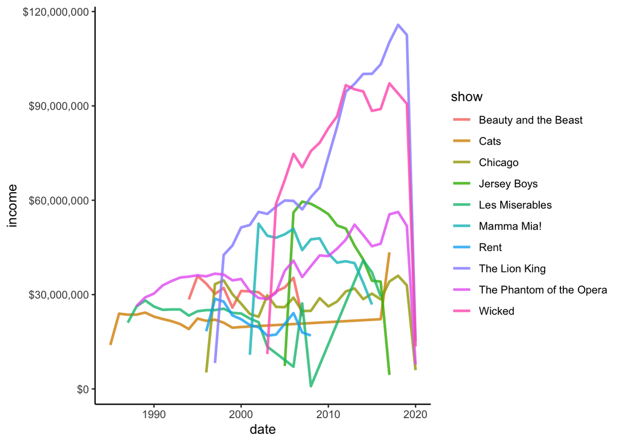

```r
grosses%>%
  filter(show %in% c("The Phantom of the Opera","Chicago",
                     "The Lion King","Les Miserables","Cats","Wicked",
                     "Mamma Mia!","Beauty and the Beast","Jersey Boys","Rent"))%>%
  cross_by_dimensions(show)%>%
  cross_by_periods(c("year"))%>%
  summarize(income=sum(weekly_gross),
            avg_ticket_price=mean(avg_ticket_price))%>%
  filter(show!="All")%>%
  ggplot(aes(date,income,color=show))+
  geom_line(size=1,alpha=.8)+
  scale_y_continuous(labels = dollar)
```

Imagine working with this in econometrics, is Awsome!!! And now create your Dashboard. The first step is save your metrics.

```r
show_summarized<-grosses%>%
  filter(show %in% c("The Phantom of the Opera","Chicago",
                     "The Lion King","Les Miserables","Cats","Wicked",
                     "Mamma Mia!","Beauty and the Beast","Jersey Boys","Rent"))%>%
  cross_by_dimensions(show)%>%
  filter(show!="All")%>%
  cross_by_periods(c("year","month","week"))%>%
  summarize(income=sum(weekly_gross),
            avg_ticket_price=mean(avg_ticket_price),
            pct_capacity=mean(pct_capacity))%>%
  mutate(variation_ticke_price=round(avg_ticket_price-lag(avg_ticket_price),2))%>%
  ungroup()
```

With `use_metrics_scaffold` you create the first step and the most important input for create your Dashboard, copy and paste in the HEAD

```r
use_metrics_scaffold(show_summarized)
```

```
## metrics:
##   income:
##     title: <TODO>
##     description: <TODO>
##   avg_ticket_price:
##     title: <TODO>
##     description: <TODO>
##   pct_capacity:
##     title: <TODO>
##     description: <TODO>
##   variation_ticke_price:
##     title: <TODO>
##     description: <TODO>
## dimensions:
##   show:
##     title: <TODO>
##     description: <TODO>
```

```r
title: "bordway dash"
name: metrics_for_shows
owner: cjimenez187@aol.com
metrics:
  income:
    title: Total Income
    description: Total Income per year
  avg_ticket_price:
    title: Average ticket price
    description: This is average ticket price per year
  pct_capacity:
    title: Percet capacity
    description: "Percent capacity(in seats) for theater"
  variation_ticke_price:
    title: Mean Variation price Tickets
    description: Mean Variation price Tickets
dimensions:
  show:
    title: Show`s
    description: "Top 10 Shows"
```

And next step is create metrics

```r
show_metrics<-create_metrics(show_summarized)
```

And finally you can use preview_metric for your dashboard.

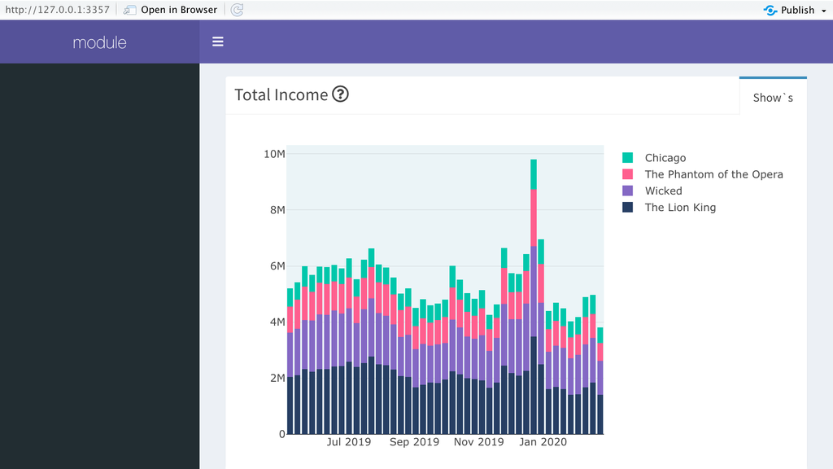

Is the most similar that [looker](https://looker.com/)

You can find my Dashboard final version [here](https://danieljimenez.shinyapps.io/Brodway/), and de code [here](https://github.com/carlosjimenez88M/Dashboards)